# R Notebook

# 9.2 Detecting cancer driver genes based on positional clustering

Concept of detecting the cancer driven gene based on positional clustring is based on the fact that most of the variants in cancer causing genes are enriched at few specific loci (aka hot-spots). This method takes advantage of such positions to identify cancer genes

```r
laml.sig = oncodrive(maf = laml, AACol = 'Protein_Change', minMut = 5, pvalMethod = 'zscore')
```

```
## Estimating background scores from synonymous variants..
```

```
## Not enough genes to build background. Using predefined values. (Mean = 0.279; SD = 0.13)
```

```
## Estimating cluster scores from non-syn variants..
```

```
## Comapring with background model and estimating p-values..
```

```
## Done !
```

```r
head(laml.sig)
```

| Hugo_Symbol | Frame_Shift_Del | Frame_Shift_Ins | In_Frame_Del | In_Frame_Ins | Missense_Mutation | Nonsense_Mutation | Splice_Site | total | MutatedSamples | AlteredSamples | clusters | muts_in_clusters | clusterScores | protLen | zscore | pval | fdr | fract_muts_in_clusters |
| --- | --- | --- | --- | --- | --- | --- | --- | --- | --- | --- | --- | --- | --- | --- | --- | --- | --- | --- |
| IDH1 | 0 | 0 | 0 | 0 | 18 | 0 | 0 | 18 | 18 | 18 | 1 | 18 | 1.0000000 | 414 | 5.546154 | 1.460110e-08 | 1.022077e-07 | 1.0000000 |
| IDH2 | 0 | 0 | 0 | 0 | 20 | 0 | 0 | 20 | 20 | 20 | 2 | 20 | 1.0000000 | 452 | 5.546154 | 1.460110e-08 | 1.022077e-07 | 1.0000000 |
| NPM1 | 0 | 33 | 0 | 0 | 1 | 0 | 0 | 34 | 33 | 33 | 2 | 32 | 0.9411765 | 294 | 5.093665 | 1.756034e-07 | 8.194826e-07 | 0.9411765 |
| NRAS | 0 | 0 | 0 | 0 | 15 | 0 | 0 | 15 | 15 | 15 | 2 | 15 | 0.9218951 | 189 | 4.945347 | 3.800413e-07 | 1.330144e-06 | 1.0000000 |
| U2AF1 | 0 | 0 | 0 | 0 | 8 | 0 | 0 | 8 | 8 | 8 | 1 | 7 | 0.8750000 | 240 | 4.584615 | 2.274114e-06 | 6.367520e-06 | 0.8750000 |
| KIT | 1 | 1 | 0 | 1 | 7 | 0 | 0 | 10 | 8 | 8 | 2 | 9 | 0.8500000 | 976 | 4.392308 | 5.607691e-06 | 1.308461e-05 | 0.9000000 |

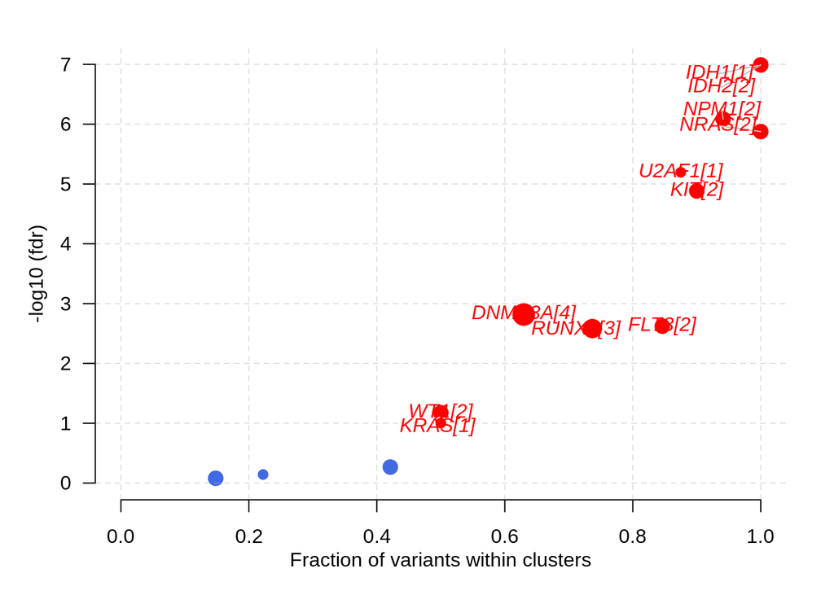

```r
plotOncodrive(res = laml.sig, fdrCutOff = 0.1, useFraction = TRUE)
```

# 9.3 Adding and summarizing pfam domains pfamDomains adds pfam domain information to the amino acid changes and also summarizes amino acid changes according to the domains that are affected.

```r
laml.pfam = pfamDomains(maf = laml, AACol = 'Protein_Change', top = 10)
```

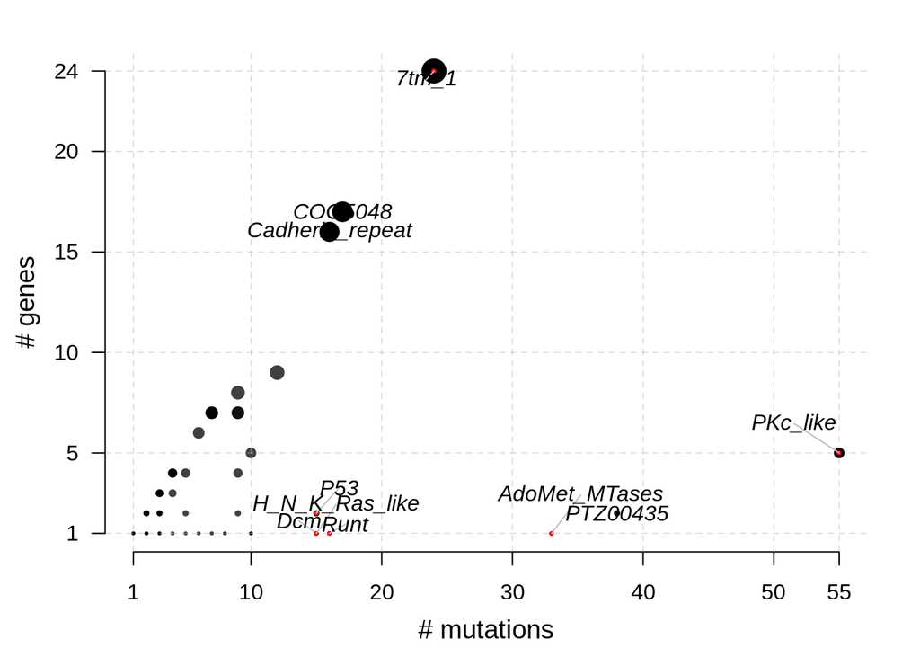

```r
#Protein summary (Printing first 7 columns for display convenience)
laml.pfam$proteinSummary[,1:7, with = FALSE]
```

| HGNC | AAPos | Variant_Classification | N | total | fraction | DomainLabel |
| --- | --- | --- | --- | --- | --- | --- |
| DNMT3A | 882 | Missense_Mutation | 27 | 54 | 0.50000000 | AdoMet_MTases |
| IDH1 | 132 | Missense_Mutation | 18 | 18 | 1.00000000 | PTZ00435 |
| IDH2 | 140 | Missense_Mutation | 17 | 20 | 0.85000000 | PTZ00435 |
| FLT3 | 835 | Missense_Mutation | 14 | 52 | 0.26923077 | PKc_like |
| FLT3 | 599 | In_Frame_Ins | 10 | 52 | 0.19230769 | PKc_like |
| U2AF1 | 34 | Missense_Mutation | 7 | 8 | 0.87500000 | zf-CCCH |
| NRAS | 61 | Missense_Mutation | 6 | 15 | 0.40000000 | H_N_K_Ras_like |
| KIT | 816 | Missense_Mutation | 5 | 10 | 0.50000000 | PTKc_Kit |
| NRAS | 13 | Missense_Mutation | 5 | 15 | 0.33333333 | H_N_K_Ras_like |
| FLT3 | 601 | In_Frame_Ins | 4 | 52 | 0.07692308 | PKc_like |

[output cut: 1506 more lines]

```r
#Domain summary (Printing first 3 columns for display convenience)
laml.pfam$domainSummary[,1:3, with = FALSE]
```

| DomainLabel | nMuts | nGenes |
| --- | --- | --- |
| PKc_like | 55 | 5 |
| PTZ00435 | 38 | 2 |
| AdoMet_MTases | 33 | 1 |
| 7tm_1 | 24 | 24 |
| COG5048 | 17 | 17 |
| Cadherin_repeat | 16 | 16 |
| Runt | 16 | 1 |
| Dcm | 15 | 1 |
| H_N_K_Ras_like | 15 | 1 |
| P53 | 15 | 2 |

[output cut: 493 more lines]

# 9.4 Pan-Cancer comparison

comparing mutSig results against this pan-can list of significantly mutated genes to see genes specifically mutated in given cohort. This function requires MutSigCV results

```r
#MutsigCV results for TCGA-AML
laml.mutsig <- system.file("extdata", "LAML_sig_genes.txt.gz", package = "maftools")
pancanComparison(mutsigResults = laml.mutsig, qval = 0.1, cohortName = 'LAML', inputSampleSize = 200, label = 1)
```

```
## Significantly mutated genes in LAML (q < 0.1): 23
```

```
## Significantly mutated genes in PanCan cohort (q <0.1): 114
```

```
## Significantly mutated genes exclusive to LAML (q < 0.1):
```

```
##       gene pancan            q nMut log_q_pancan     log_q
##  1:  CEBPA  1.000 3.500301e-12   13   0.00000000 11.455895
##  2:   EZH2  1.000 7.463546e-05    3   0.00000000  4.127055
##  3: GIGYF2  1.000 6.378338e-03    2   0.00000000  2.195292
##  4:    KIT  0.509 1.137517e-05    8   0.29328222  4.944042
##  5:   PHF6  0.783 6.457555e-09    6   0.10623824  8.189932
##  6: PTPN11  0.286 7.664584e-03    9   0.54363397  2.115511
##  7:  RAD21  0.929 1.137517e-05    5   0.03198429  4.944042
##  8:  SMC1A  0.801 2.961696e-03    6   0.09636748  2.528460
##  9:   TET2  0.907 2.281625e-13   17   0.04239271 12.641756
## 10:    WT1  1.000 2.281625e-13   12   0.00000000 12.641756
```

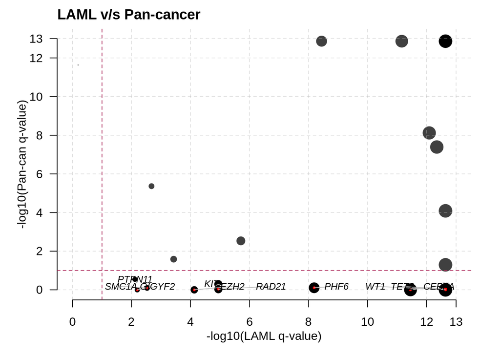

| gene | pancan | q | nMut | log_q_pancan | log_q |
| --- | --- | --- | --- | --- | --- |
| ACVR1B | 6.11e-02 | 1.000000e+00 | 0 | 1.21395879 | 0.0000000 |
| AKT1 | 2.68e-10 | 1.000000e+00 | 0 | 9.57186521 | 0.0000000 |
| APC | 1.36e-13 | 1.000000e+00 | 0 | 12.86646109 | 0.0000000 |
| APOL2 | 7.96e-03 | 1.000000e+00 | 0 | 2.09908693 | 0.0000000 |
| ARHGAP35 | 2.32e-12 | 1.000000e+00 | 1 | 11.63451202 | 0.0000000 |
| ARID1A | 2.32e-12 | 1.000000e+00 | 1 | 11.63451202 | 0.0000000 |
| ARID2 | 1.03e-06 | 1.000000e+00 | 1 | 5.98716278 | 0.0000000 |
| ASXL1 | 4.33e-06 | 2.098493e-03 | 5 | 5.36351210 | 2.6780925 |
| ASXL2 | 8.18e-02 | 1.000000e+00 | 1 | 1.08724670 | 0.0000000 |
| ATM | 5.85e-10 | 1.000000e+00 | 0 | 9.23284413 | 0.0000000 |

[output cut: 114 more lines]

#9.5 Survival analysis # 9.5.1 Mutation in any given genes Function mafSurvive performs survival analysis and draws kaplan meier curve by grouping samples based on mutation status of user defined gene(s) or manually provided samples those make up a group. This function requires input data to contain Tumor_Sample_Barcode (make sure they match to those in MAF file), binary event (1/0) and time to event.

```r
#Survival analysis based on grouping of DNMT3A mutation status
mafSurvival(maf = laml, genes = 'DNMT3A', time = 'days_to_last_followup', Status = 'Overall_Survival_Status', isTCGA = TRUE)
```

```
## Looking for clinical data in annoatation slot of MAF..
```

```
## Number of mutated samples for given genes:
```

```
## DNMT3A
##     48
```

```
## Removed 11 samples with NA's
```

```
## Median survival..
```

```
##     Group medianTime   N
## 1: Mutant        245  45
## 2:     WT        396 137
```

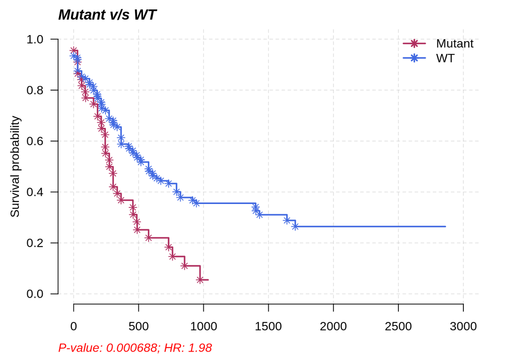

# 9.5.2 Predict genesets associated with survival

```r
#Using top 20 mutated genes to identify a set of genes (of size 2) to predict poor prognostic groups
prog_geneset = survGroup(maf = laml, top = 20, geneSetSize = 2, time = "days_to_last_followup", Status = "Overall_Survival_Status", verbose = FALSE)
```

```
## Removed 11 samples with NA's
```